# HOMEWORK 5

ilaydacelenk

15/02/2021

```r
#importing the libraries
library(tidyverse) #filter etc.
library(ggplot2)
library(reshape) #melt
library(directlabels)
library(dplyr)
library(data.table) #data.table
library(caret)
library(TunePareto) #generateCVRuns
library(glmnet)
library(kknn)
library(penalized)
```

# Introduction:

The first task is on uWaveGestureLibrary. It consists over 4000 three-axis accelerometer instances from 8 people with 8 different gestures, our aim is to perform classification task by Nearest Neighbor Approach. Then, the second task is to use a penalized regression approach to classify given EcG data.

# Task 1

```r
#reading the data from repository
x_train<-read.table("https://github.com/BU-IE-582/fall20-ilaydacelenk/blob/master/files/HW2_data/uWaveGestureLibrary_X_TRAIN.txt?raw=true") %>% as.data.frame()
y_train<-read.table("https://github.com/BU-IE-582/fall20-ilaydacelenk/blob/master/files/HW2_data/uWaveGestureLibrary_Y_TRAIN.txt?raw=true") %>% as.data.frame()
z_train<-read.table("https://github.com/BU-IE-582/fall20-ilaydacelenk/blob/master/files/HW2_data/uWaveGestureLibrary_Z_TRAIN.txt?raw=true") %>% as.data.frame()

x_test<-read.table("https://github.com/BU-IE-582/fall20-ilaydacelenk/blob/master/files/HW2_data/uWaveGestureLibrary_X_TEST.txt?raw=true") %>% as.data.frame()
y_test<-read.table("https://github.com/BU-IE-582/fall20-ilaydacelenk/blob/master/files/HW2_data/uWaveGestureLibrary_Y_TEST.txt?raw=true") %>% as.data.frame()
z_test<-read.table("https://github.com/BU-IE-582/fall20-ilaydacelenk/blob/master/files/HW2_data/uWaveGestureLibrary_Z_TEST.txt?raw=true") %>% as.data.frame()

x_name <- c("x")
x_names <- c()
for(i in 1:ncol(x_train)){
  x_names <- x_names %>% append(x_name)
}
colnames(x_train) <- make.names(x_names, unique=TRUE)
colnames(x_test) <- make.names(x_names, unique=TRUE)

y_name <- c("y")
y_names <- c()
for(i in 1:ncol(y_train)){
  y_names <- y_names %>% append(y_name)
}
colnames(y_train) <- make.names(y_names, unique=TRUE)
colnames(y_test) <- make.names(y_names, unique=TRUE)

z_name <- c("z")
z_names <- c()
for(i in 1:ncol(z_train)){
  z_names <- z_names %>% append(z_name)
}
colnames(z_train) <- make.names(z_names, unique=TRUE)
colnames(z_test) <- make.names(z_names, unique=TRUE)
```

```r
train <- cbind(x_train[,-1], y_train[,-1], z_train[,-1]) %>% scale()
test <- cbind(x_test[,-1], y_test[,-1], z_test[,-1]) %>% scale()

class <- x_train[,1]
train_class <- class
trainn <- cbind(class, train) %>% as.data.frame()
trainn$class <- sub("^", "g", trainn$class) %>% as.factor()

class <- x_test[,1]
test_class <- class
testt <- cbind(class, test) %>% as.data.frame()
testt$class <- sub("^", "g", testt$class) %>% as.factor()
```

## Task1a

```r
set.seed(3)
k_levels <- c(1, 3, 5, 7, 9, 11, 13, 15)
nofReplications <- 3
nFolds <- 10
#for balanced folds: stratified =TRUE
indices <- generateCVRuns(trainn$class, ntimes=nofReplications, nfold=nFolds, stratified=TRUE)
cv_results <- data.table()

for(i in 1:nofReplications) {
  rep<-indices[[i]]
  for(j in 1:nFolds){
   test_ind<-rep[[j]]
   cv_train<-trainn[-test_ind,]
   cv_test<-trainn[test_ind,]

   for(m in 1:length(k_levels)){
      k_tune <- k_levels[m]
      model_knn_euc <- kknn(class~., cv_train, cv_test, k = k_tune, kernel="rectangular", distance=2)
      pred <- model_knn_euc[["fitted.values"]]
      cm_test_man <- confusionMatrix(pred, cv_test$class)
      cv_results <- rbind(cv_results, data.table(Replication=i, Fold=j, K=k_tune, TestId=test_ind,
                                         Predictions=pred, Actual=cv_test$class))
    }

  }

}

Euclidean_result <- cv_results[,list(Accuracy=mean(Predictions==Actual)),by=list(K)] %>% arrange(desc(Accuracy))
Euclidean_result
```

```
FALSE     K  Accuracy
FALSE 1:  3 0.9494048
FALSE 2:  1 0.9441964
FALSE 3:  5 0.9412202
FALSE 4:  7 0.9378720
FALSE 5:  9 0.9308036
FALSE 6: 11 0.9293155
FALSE 7: 13 0.9281994
FALSE 8: 15 0.9244792
```

```r
besk_k <- as.matrix(Euclidean_result)

euc_time <- system.time(
  model_knn_euc <- kknn(class~., trainn, testt, k = besk_k[1,1], kernel="rectangular", distance=2)
)

model_knn_euc2 <- kknn(class~., trainn, trainn, k = besk_k[1,1], kernel="rectangular", distance=2)



## REMARK
# Alternatively, we could also use the train function from caret, it will give the same result, for the best tune it gives the same accuracy (I checked)
#k_levels <- c(1, 3, 5, 7, 9, 11, 13, 15)
#nofReplications <- 1
#nFolds <- 10
#fitControl <- trainControl(method = "repeatedcv", number = nFolds, repeats = nofReplications, savePred = TRUE, classProbs = TRUE)
#grid <- expand.grid(k=k_levels)
#model_knn_euc <- train(class ~ ., data = trainn, method = "knn", trControl = fitControl, tuneGrid = grid)
#pred_euc <- predict(model_knn_euc, newdata=test)
```

Using Euclidean distance, I applied a 10-fold cross-validation nearest-neighbor classifier. The number of neighbors (k) that minimizes the error is found as 3.

```r
set.seed(1)
k_levels <- c(1, 3, 5, 7, 9, 11, 13, 15)
nofReplications <- 3
nFolds <- 10
#for balanced folds: stratified =TRUE
indices <- generateCVRuns(trainn$class, ntimes=nofReplications, nfold=nFolds, stratified=TRUE)
cv_results <- data.table()

for(i in 1:nofReplications) {
  rep<-indices[[i]]
  for(j in 1:nFolds){
   test_ind<-rep[[j]]
   cv_train<-trainn[-test_ind,]
   cv_test<-trainn[test_ind,]

   for(m in 1:length(k_levels)){
      k_tune <- k_levels[m]
      model_knn_man <- kknn(class~., cv_train, cv_test, k = k_tune, kernel="rectangular", distance=1)
      pred <- model_knn_man[["fitted.values"]]
      cm_test_man <- confusionMatrix(pred, cv_test$class)
      cv_results <- rbind(cv_results, data.table(Replication=i, Fold=j, K=k_tune, TestId=test_ind,
                                         Predictions=pred, Actual=cv_test$class))
    }

  }

}

Manhattan_result <- cv_results[,list(Accuracy=mean(Predictions==Actual)),by=list(K)] %>% arrange(desc(Accuracy))
Manhattan_result
```

```
FALSE     K  Accuracy
FALSE 1:  3 0.9594494
FALSE 2:  1 0.9568452
FALSE 3:  5 0.9531250
FALSE 4:  7 0.9475446
FALSE 5:  9 0.9453125
FALSE 6: 11 0.9408482
FALSE 7: 13 0.9367560
FALSE 8: 15 0.9345238
```

```r
besk_k <- as.matrix(Manhattan_result)

man_time <- system.time(
  model_knn_man <- kknn(class~., trainn, testt, k = besk_k[1,1], kernel="rectangular", distance=1)
)

model_knn_man2 <- kknn(class~., trainn, trainn, k = besk_k[1,1], kernel="rectangular", distance=1)
```

I used Manhattan distance in a similar manner. The number of neighbors (k) that minimizes the error is found as 3.

## Task1b

```r
cm_test_euc <- confusionMatrix(model_knn_euc[["fitted.values"]], testt$class)
cm_train_euc <- confusionMatrix(model_knn_euc2[["fitted.values"]], trainn$class)
print(cm_test_euc[["table"]])
```

```
FALSE           Reference
FALSE Prediction  g1  g2  g3  g4  g5  g6  g7  g8
FALSE         g1 429   1   1   5   3   5   0   0
FALSE         g2   0 449   0   0   0   0   0   0
FALSE         g3   0   0 414   0   6   5   2   0
FALSE         g4   3   0   0 372   1  14   0   1
FALSE         g5   0   0  14  59 421  29   0   1
FALSE         g6   4   0  21   8   2 395   0   0
FALSE         g7   1   2   4   0   0   1 445   0
FALSE         g8   0   0   0   6   0   0   0 458
```

```r
print(cm_train_euc[["table"]])
```

```
FALSE           Reference
FALSE Prediction  g1  g2  g3  g4  g5  g6  g7  g8
FALSE         g1 120   0   0   1   0   1   0   0
FALSE         g2   0 108   0   0   0   0   0   0
FALSE         g3   0   0 104   0   0   1   0   0
FALSE         g4   0   0   0  99   0   3   0   0
FALSE         g5   0   0   0   9 127   3   0   0
FALSE         g6   2   0   1   0   0 103   0   0
FALSE         g7   0   0   1   0   0   0 112   0
FALSE         g8   0   0   0   1   0   0   0 100
```

```r
cm_test_euc[["overall"]][["Accuracy"]]
```

```
FALSE [1] 0.9444444
```

```r
cm_train_euc[["overall"]][["Accuracy"]]
```

```
FALSE [1] 0.9743304
```

```r
euc_time
```

```
FALSE    user  system elapsed
FALSE   3.631   0.061   3.698
```

Using best k value for Euclidean distance, I evaluated the performance on both test and train set as 94.44% and 97.43% respectively. Confusion matrices are shown above, first for the test data then for the train data. The runtime for euclidean distance to predict is 3.631, 0.061, 3.698, 0, 0.

```r
cm_test_man <- confusionMatrix(model_knn_man[["fitted.values"]], testt$class)
cm_train_man <- confusionMatrix(model_knn_man2[["fitted.values"]], trainn$class)
print(cm_test_man[["table"]])
```

```
FALSE           Reference
FALSE Prediction  g1  g2  g3  g4  g5  g6  g7  g8
FALSE         g1 432   1   2   3   3   6   1   0
FALSE         g2   0 451   0   0   0   0   0   0
FALSE         g3   0   0 415   0   4   4   2   0
FALSE         g4   2   0   0 384   2  12   0   1
FALSE         g5   0   0  12  48 422  27   0   1
FALSE         g6   3   0  20   8   2 400   0   0
FALSE         g7   0   0   5   0   0   0 444   0
FALSE         g8   0   0   0   7   0   0   0 458
```

```r
print(cm_train_man[["table"]])
```

```
FALSE           Reference
FALSE Prediction  g1  g2  g3  g4  g5  g6  g7  g8
FALSE         g1 121   0   0   1   0   0   0   0
FALSE         g2   0 108   0   0   0   0   0   0
FALSE         g3   0   0 104   0   0   1   0   0
FALSE         g4   0   0   0 102   1   3   0   0
FALSE         g5   0   0   0   6 126   2   0   0
FALSE         g6   1   0   1   0   0 105   0   0
FALSE         g7   0   0   1   0   0   0 112   0
FALSE         g8   0   0   0   1   0   0   0 100
```

```r
cm_test_man[["overall"]][["Accuracy"]]
```

```
FALSE [1] 0.9508654
```

```r
cm_train_man[["overall"]][["Accuracy"]]
```

```
FALSE [1] 0.9799107
```

```r
man_time
```

```
FALSE    user  system elapsed
FALSE  54.586   0.135  54.789
```

## Task1c

If we compute the distance as final_dist = w1dist_x, + w2dist_y + w3*dist_z, the nearest neighbors may change. This would affect the classification result. I would expect the standard deviation of x-axis to be high, due to the nature of gestures and I expect this axis to be more effective. So, giving it more weight could be reasonable.

# Task 2

```r
#reading the data from repository
ecg_train<-read.table("https://github.com/BU-IE-582/fall20-ilaydacelenk/blob/master/files/ecgTRAIN.txt?raw=true")
ecg_test<-read.table("https://github.com/BU-IE-582/fall20-ilaydacelenk/blob/master/files/ecgTEST.txt?raw=true")
# map -1-1 to 0-1
ecg_train[,1][(ecg_train[,1]==-1)] <- 0
ecg_test[,1][(ecg_test[,1]==-1)] <- 0
```

In this task, given ECG data, the aim is to train different logistic regression models using fused lasso penalties. Above, first I read the datasets and since the target columns consists of -1 and 1’s, I map them into 0-1. I do this by mapping -1 to 0 and keeping 1’s as they are.

## Task 2a

```r
set.seed(1)
logreg1 <- optL1(response=ecg_train[,1], penalized=ecg_train[,-1],fusedl = TRUE, fold = 10, model = "logistic")
```

```
FALSE lambda= 8.548129  12345678910cvl= -47.91835
FALSE lambda= 13.83116  12345678910cvl= -55.22797
FALSE lambda= 5.283034  12345678910cvl= -41.40059
FALSE lambda= 3.265095  12345678910cvl= -37.5193
FALSE lambda= 2.017939  12345678910cvl= -36.5004
FALSE lambda= 1.436027  12345678910cvl= -37.02119
FALSE lambda= 2.205082  12345678910cvl= -36.47056
FALSE lambda= 2.194867  12345678910cvl= -36.47008
FALSE lambda= 2.179852  12345678910cvl= -36.46972
FALSE lambda= 2.118007  12345678910cvl= -36.47313
FALSE lambda= 2.174073  12345678910cvl= -36.46969
FALSE lambda= 2.174176  12345678910cvl= -36.46975
FALSE lambda= 2.152658  12345678910cvl= -36.47012
FALSE lambda= 2.165893  12345678910cvl= -36.46975
FALSE lambda= 2.170949  12345678910cvl= -36.4697
FALSE lambda= 2.17288   12345678910cvl= -36.46969
FALSE lambda= 2.173617  12345678910cvl= -36.46969
```

```r
optlambda1 <- logreg1$lambda
logreg2<-optL2(response=ecg_train[,1], penalized=ecg_train[,-1], fusedl = TRUE, fold = 10, model = "logistic", lambda1=optlambda1, minlambda2 = 0.5)
```

```
FALSE lambda= Inf   cvl= -62.61648
FALSE lambda= 0.5   12345678910cvl= -37.39543
FALSE lambda= 5     12345678910cvl= -40.29091
FALSE lambda= 2.218847  12345678910cvl= -37.87516
FALSE lambda= 3.281153  12345678910cvl= -39.2098
FALSE lambda= 1.562306  12345678910cvl= -37.44149
FALSE lambda= 0.9378134     12345678910cvl= -37.79447
FALSE lambda= 1.545419  12345678910cvl= -37.38885
FALSE lambda= 1.296695  12345678910cvl= -37.40119
FALSE lambda= 1.450415  12345678910cvl= -37.33382
FALSE lambda= 1.427117  12345678910cvl= -37.32608
FALSE lambda= 1.377301  12345678910cvl= -37.33529
FALSE lambda= 1.41528   12345678910cvl= -37.32223
FALSE lambda= 1.400773  12345678910cvl= -37.32322
FALSE lambda= 1.410314  12345678910cvl= -37.32063
FALSE lambda= 1.408863  12345678910cvl= -37.32082
FALSE lambda= 1.41051   12345678910cvl= -37.32069
FALSE lambda= 1.409829  12345678910cvl= -37.3206
FALSE lambda= 1.40946   12345678910cvl= -37.32068
FALSE lambda= 1.409887  12345678910cvl= -37.32059
FALSE lambda= 1.410071  12345678910cvl= -37.32055
```

```r
optlambda2 <- logreg2$lambda
model<-penalized(response=ecg_train[,1], penalized=ecg_train[,-1], fusedl = TRUE, model = "logistic", data=ecg_train, lambda1 = optlambda1, lambda2 = optlambda2)
```

```r
pred_train <- predict(model, penalized=ecg_train[,-1], data=ecg_train)
pred_train[pred_train>0.5] <- 1
pred_train[pred_train<=0.5] <- 0
cm_train <- confusionMatrix(as.factor(pred_train), as.factor(ecg_train$V1))

pred_test <- predict(model,penalized=ecg_test[,-1],data=ecg_test)
pred_test[pred_test>0.5] <- 1
pred_test[pred_test<=0.5] <- 0
cm_test <- confusionMatrix(as.factor(pred_test), as.factor(ecg_test$V1))

print(cm_test[["table"]])
```

```
FALSE           Reference
FALSE Prediction  0  1
FALSE          0 24  7
FALSE          1 12 57
```

```r
print(cm_train[["table"]])
```

```
FALSE           Reference
FALSE Prediction  0  1
FALSE          0 23  6
FALSE          1  8 63
```

Above, I trained a logistic regression model using fused lasso penalties on ECG data. I used the learned model to predict the class for test data. I evaluated the performance on both test and train set as 81% and 86%, respectively. Even though the accuracy for train data is high, it is not 100%, therefore there is no big overfitting problem. Confusion matrices are shown above, first for the test data then for the train data.

## Task 2b

```r
model
```

```
FALSE Penalized logistic regression object
FALSE 97 regression coefficients of which 21 are non-zero
FALSE
FALSE Loglikelihood =    -29.58561
FALSE L1 penalty =   8.885764   at lambda1 =  2.174073
FALSE L2 penalty =   2.506205   at lambda2 =  1.410071
```

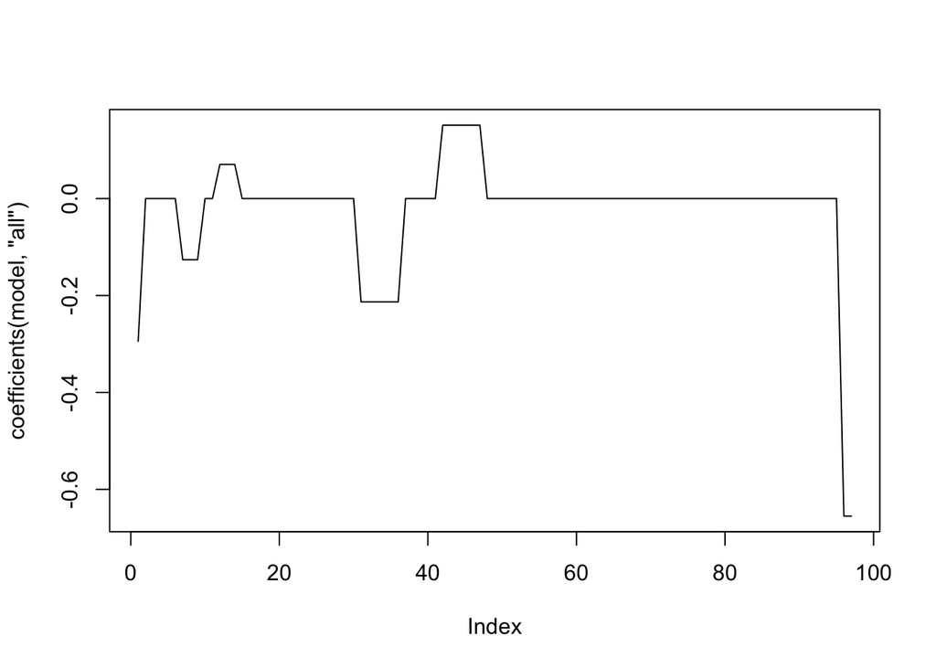

```r
coefs <- coefficients(model,"all")
plot(coefficients(model,"all"), type="l")
```

The coefficient are nearly zero when the plot is flat. There are 21 nonzero coefficients in the model.

## Task 2c

```r
train2<-matrix(0,nrow = 100,ncol=96) # empty matrix
train2[,1]<-ecg_train[,1] # target column
for(i in (3:96)){
  train2[,(i-1)]=ecg_train[,i]-ecg_train[,(i-1)]
}

test2<-matrix(0,nrow = 100,ncol=96) # empty matrix
test2[,1]<-ecg_test[,1] # target column
for(i in (3:96)){
  test2[,(i-1)]=ecg_test[,i]-ecg_test[,(i-1)]
}

train2 <- train2 %>% data.frame()
test2 <- test2 %>% data.frame()
```

Above, I create a matrix for the train data which consists of the consecutive differences of instances. This makes sense and can be done since it is a time series data. I do the same for the test data. Below I will train the model on the consecutive differences data.

```r
set.seed(1)
logreg3 <- optL1(response=train2[,1], penalized=train2[,-1], fusedl = TRUE, fold = 10, data=train2, model = "logistic")
```

```
FALSE lambda= 5.59004   12345678910cvl= -51.7503
FALSE lambda= 9.044875  12345678910cvl= -55.79921
FALSE lambda= 3.454835  12345678910cvl= -50.31286
FALSE lambda= 0.7497166     12345678910cvl= -45.00509
FALSE lambda= 1.78298   12345678910cvl= -44.36937
FALSE lambda= 1.465895  12345678910cvl= -43.2478
FALSE lambda= 1.319406  12345678910cvl= -42.49278
FALSE lambda= 1.101804  12345678910cvl= -41.95785
FALSE lambda= 1.044601  12345678910cvl= -42.13642
FALSE lambda= 1.150072  12345678910cvl= -41.88783
FALSE lambda= 1.171714  12345678910cvl= -41.92534
FALSE lambda= 1.141865  12345678910cvl= -41.87757
FALSE lambda= 1.126563  12345678910cvl= -41.90369
FALSE lambda= 1.140999  12345678910cvl= -41.8782
FALSE lambda= 1.143111  12345678910cvl= -41.87818
FALSE lambda= 1.142064  12345678910cvl= -41.87742
FALSE lambda= 1.142276  12345678910cvl= -41.87727
FALSE lambda= 1.142595  12345678910cvl= -41.8775
FALSE lambda= 1.14233   12345678910cvl= -41.87723
```

```r
optlambda3 <- logreg3$lambda

logreg4 <- optL2(response=train2[,1], penalized=train2[,-1], fusedl = TRUE, fold = 10, data=train2, model = "logistic", lambda1=optlambda3, minlambda2 = 5)
```

```
FALSE lambda= Inf   cvl= -62.61648
FALSE lambda= 5     12345678910cvl= -52.0904
FALSE lambda= 50    12345678910cvl= -60.38104
FALSE lambda= 22.18847  12345678910cvl= -62.07367
FALSE lambda= 32.81153  12345678910cvl= -62.80064
FALSE lambda= 15.62306  12345678910cvl= -61.03053
FALSE lambda= 11.56541  12345678910cvl= -57.87603
FALSE lambda= 9.057647  12345678910cvl= -56.75188
FALSE lambda= 5.840841  12345678910cvl= -54.04102
FALSE lambda= 7.069552  12345678910cvl= -55.95597
FALSE lambda= 6.310167  12345678910cvl= -55.02203
FALSE lambda= 5.519668  12345678910cvl= -53.34443
FALSE lambda= 5.321173  12345678910cvl= -52.87409
FALSE lambda= 5.198496  12345678910cvl= -52.58291
FALSE lambda= 5.122677  12345678910cvl= -52.39623
FALSE lambda= 5.075819  12345678910cvl= -52.27909
FALSE lambda= 5.046858  12345678910cvl= -52.20689
FALSE lambda= 5.02896   12345678910cvl= -52.16234
FALSE lambda= 5.017898  12345678910cvl= -52.13485
FALSE lambda= 5.011062  12345678910cvl= -52.11786
FALSE lambda= 5.006837  12345678910cvl= -52.10737
FALSE lambda= 5.004225  12345678910cvl= -52.10089
FALSE lambda= 5.002611  12345678910cvl= -52.09688
FALSE lambda= 5.001614  12345678910cvl= -52.09441
FALSE lambda= 5.000997  12345678910cvl= -52.09288
```

```r
optlambda4 <- logreg4$lambda

model2<-penalized(response=train2[,1], penalized=train2[,-1], fusedl = TRUE, model = "logistic", data=train2, lambda1 = optlambda3, lambda2 = optlambda4)
```

```r
pred_train <- predict(model2,penalized=train2[,-1], data=train2)
pred_train[pred_train>0.5] <- 1
pred_train[pred_train<=0.5] <- 0
cm_train <- confusionMatrix(as.factor(pred_train), as.factor(train2$X1))


pred_test <- predict(model2,penalized=train2[,-1], data=train2)
pred_test[pred_test>0.5] <- 1
pred_test[pred_test<=0.5] <- 0
cm_test <- confusionMatrix(as.factor(pred_test), as.factor(test2$X1))


print(cm_test[["table"]])
```

```
FALSE           Reference
FALSE Prediction  0  1
FALSE          0  6 12
FALSE          1 30 52
```

```r
print(cm_train[["table"]])
```

```
FALSE           Reference
FALSE Prediction  0  1
FALSE          0 15  3
FALSE          1 16 66
```

## Task 2d

```r
model2
```

```
FALSE Penalized logistic regression object
FALSE 96 regression coefficients of which 18 are non-zero
FALSE
FALSE Loglikelihood =    -44.25033
FALSE L1 penalty =   4.271354   at lambda1 =  1.14233
FALSE L2 penalty =   6.874049   at lambda2 =  5.000997
```

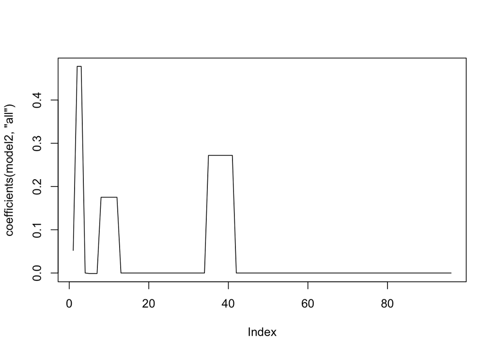

```r
coefs <- coefficients(model2,"all")
plot(coefficients(model2,"all"), type="l")
```

The coefficient are nearly zero when the plot is flat. There are 18 nonzero coefficients in the model.

## Task 2e

```r
train3 <- cbind(ecg_train, train2[,-1])
test3 <-  cbind(ecg_test, test2[,-1])

set.seed(1)
logreg5 <- optL1(response=train3[,1], penalized=train3[,-1], fusedl = TRUE, fold = 10, data=train3, model = "logistic")
```

```
FALSE lambda= 8.548129  12345678910cvl= -47.91835
FALSE lambda= 13.83116  12345678910cvl= -55.22797
FALSE lambda= 5.283034  12345678910cvl= -41.44588
FALSE lambda= 3.265095  12345678910cvl= -38.31241
FALSE lambda= 2.017939  12345678910cvl= -38.05055
FALSE lambda= 2.38626   12345678910cvl= -37.76554
FALSE lambda= 2.547736  12345678910cvl= -37.80611
FALSE lambda= 2.402071  12345678910cvl= -37.76263
FALSE lambda= 2.424931  12345678910cvl= -37.76015
FALSE lambda= 2.471838  12345678910cvl= -37.77457
FALSE lambda= 2.441513  12345678910cvl= -37.7649
FALSE lambda= 2.418925  12345678910cvl= -37.75929
FALSE lambda= 2.417133  12345678910cvl= -37.75961
FALSE lambda= 2.420209  12345678910cvl= -37.75906
FALSE lambda= 2.422012  12345678910cvl= -37.75933
FALSE lambda= 2.420403  12345678910cvl= -37.75902
FALSE lambda= 2.421017  12345678910cvl= -37.75906
FALSE lambda= 2.420613  12345678910cvl= -37.75899
```

```r
optlambda5 <- logreg5$lambda

logreg6 <- optL2(response=train3[,1], penalized=train3[,-1], fusedl = TRUE, fold = 10, model = "logistic", data=train3, lambda1=optlambda5, minlambda2 = 0.5)
```

```
FALSE lambda= Inf   cvl= -62.61648
FALSE lambda= 0.5   12345678910cvl= -38.24758
FALSE lambda= 5     12345678910cvl= -42.56478
FALSE lambda= 2.218847  12345678910cvl= -40.30405
FALSE lambda= 3.281153  12345678910cvl= -41.76461
FALSE lambda= 1.562306  12345678910cvl= -40.00708
FALSE lambda= 1.46923   12345678910cvl= -38.90168
FALSE lambda= 1.099017  12345678910cvl= -38.55604
FALSE lambda= 1.26436   12345678910cvl= -38.70848
FALSE lambda= 0.8702128     12345678910cvl= -38.47092
FALSE lambda= 0.8512825     12345678910cvl= -38.44985
FALSE lambda= 0.7171046     12345678910cvl= -38.40192
FALSE lambda= 0.7480027     12345678910cvl= -38.38349
FALSE lambda= 0.7648487     12345678910cvl= -38.37535
FALSE lambda= 0.7978635     12345678910cvl= -38.38093
FALSE lambda= 0.7748947     12345678910cvl= -38.3712
FALSE lambda= 0.778025  12345678910cvl= -38.37105
FALSE lambda= 0.7772847     12345678910cvl= -38.37099
FALSE lambda= 0.7768678     12345678910cvl= -38.37102
FALSE lambda= 0.7773595     12345678910cvl= -38.37098
FALSE lambda= 0.7776137     12345678910cvl= -38.371
FALSE lambda= 0.7774492     12345678910cvl= -38.37098
```

```r
optlambda6 <- logreg6$lambda

model3<-penalized(response=train3[,1], penalized=train3[,-1], fusedl = TRUE, model = "logistic", data=train3, lambda1 = optlambda5, lambda2 = optlambda6)
```

```r
pred_train <- predict(model3, penalized=train3[,-1], data=train3)
pred_train[pred_train>0.5] <- 1
pred_train[pred_train<=0.5] <- 0
cm_train <- confusionMatrix(as.factor(pred_train), as.factor(train3$V1))

pred_test <- predict(model3, penalized=train3[,-1], data=train3)
pred_test[pred_test>0.5] <- 1
pred_test[pred_test<=0.5] <- 0
cm_test <- confusionMatrix(as.factor(pred_test), as.factor(test3$V1))

print(cm_test[["table"]])
```

```
FALSE           Reference
FALSE Prediction  0  1
FALSE          0  8 21
FALSE          1 28 43
```

```r
print(cm_train[["table"]])
```

```
FALSE           Reference
FALSE Prediction  0  1
FALSE          0 23  6
FALSE          1  8 63
```

## Task 2f

```r
model3
```

```
FALSE Penalized logistic regression object
FALSE 192 regression coefficients of which 18 are non-zero
FALSE
FALSE Loglikelihood =    -29.44766
FALSE L1 penalty =   9.654549   at lambda1 =  2.420613
FALSE L2 penalty =   2.174234   at lambda2 =  0.7773595
```

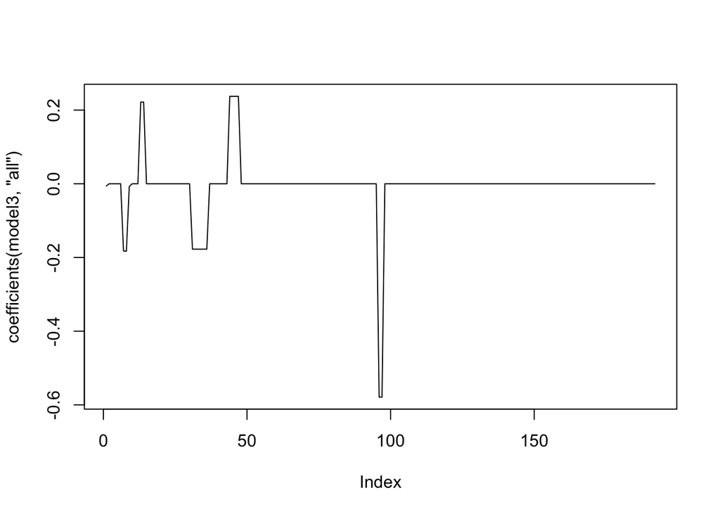

```r
coefs <- coefficients(model3,"all")
plot(coefficients(model3,"all"), type="l")
```

The coefficient are nearly zero when the plot is flat. There are 18 nonzero coefficients in the model.

# Reference

[1] J. Liu, Z. Wang, L. Zhong, J. Wickramasuriya, and V. Vasudevan. uWave: Accelerometer-based personalized gesture recognition and its applications. Pervasive Computing and Communications, IEEE International Conference on, 0:1-9, 2009. (link: https://www.recg.org/publications/liu09percom.pdf)

[2] https://cran.r-project.org/web/packages/kknn/kknn.pdf